# Survey weights are confusing… what do you do with them anyways

2020-04-11

I’m had some great opportunities to work national datasets such as National Assessment of Educational Progress [(NAEP)](https://nces.ed.gov/nationsreportcard/about/). But, throughout my use of the various datasets I’ve started diving into, I’ve kept coming up with questions about the complex design of the sampling frame. I’m slowly building my understanding of the complexities of sampling, and NAEP certainly gives me a lot of food for thought. For NAEP, these sampling design nuances boils down into multiple levels such as

- Strata,
- Schools, and
- Students

and there are even more levels and nuances. Basically, during my work with these data I’ve had a fun time trying to wrap my mind around these issues and how they influence downstream analyses. The downstream analyses is what I primarily focus on and want to try to get a better understanding on what needs to happen to appropriately handle these nuances.

I’ve been reading up on some of the issues with complex sampling design in Thomas Lumley’s [Complex Surveys text and the survey package](http://r-survey.r-forge.r-project.org/survey/). Which have been great resources for more information how these survey issues are handled in various contexts. One issue that I have not been able to find a nice solution so yet is the relationship between survey weights and Bayesian inference. Basically, I’m learning a lot and trying to figure out how survey inferences can map into these other areas I’m learning about so it’s all kinda of mess at the moment. Anyways, I’m starting to really like modeling from a Bayesian context and I’m enjoying the coding, math, and theory behind a lot of the Bayes I’ve done so far. But, this issue of survey’s hasn’t really come up yet and I wanted to dive into it a bit. This brought me to a post by Bob Carpenter [here](https://statmodeling.stat.columbia.edu/2019/10/29/non-random-missing-data-weights-generative-model/) and I’m interigued by these ideas. Which also led me back to Thomas’ blog where he talks a lot of survey designs and gives some great updates on the survey package. Next I wanted to try out some of Bob’s ideas to see if I can reproduce these issues.

# A normal data sampling issue

I’m going to take a page from some previous work I did in undergrad and build up a small population and try to bring it back down to something I can take bite out of.

So, suppose we have a population of size $N_{pop}$, which we can roughly say what this size is. We want to sample from this population to approximate what a particular parameter is, say $\theta$, of this population is. That is, we could take

1. A simple random sample of size $N_{obs}$.
2. A stratified random sample where we split the total population into groups then sample within these groups so that we get a total of $N_{obs}$.

I’m not well versed yet in the nuances of different types of stratified or cluster sampling so I’m going to try to keep this simple-ish. So lets say in the population we have a characteristic $Y$ we are interested in where
$$Y\sim N(\theta, \sigma^2)$$
so we have a relatively simple characteristic we are interested in, namely the mean/location parameter of the normal distribution. I’m gonna build this population and see what I can do to futz with it.

```r
N_pop <- 10000  # total population
mu <- 50        # population mean
sigma <- 10     # population SD
```

```r
G <- 5 # number of groups
mu_g <- rnorm(G, 0, 1) # group deviation from population mean
G_mean <- mu + mu_g # group mean
```

Now, let’s build a population that’s a little more fancy looking (and yes, I completely realize this is likely missing the forest for the trees…). I essentially just wanted to build a population where sampling proportional to size may be probablematic.

```r
G_size <- N_pop*c(0.4, 0.3, 0.1, 0.1, 0.1)

Mg <- rep(G_mean, G_size)

Y_pop <- rnorm(length(Mg), Mg, 10)
popdata <- data.frame(Y=Y_pop, G=factor(rep(1:G, G_size)))
```

Now that we have some fancy looking clustered data, let’s sample from it and see what we can get out.

## Simple random sample

Here an SRS is straightforward, we take our population $N_{pop}$ and we take a random sample from it. This means that every case is equally likely to be sampled. Or said another way, the probability of being sampled is equal for all observations.

$$\pi_i = 1/N_{pop}$$
where $\pi_i$ is the probability of being included in the sample.

```r
popdata$pi_srs <- 1/N_pop

N_obs <- 100
Y_obs <- sample(x=popdata$Y, size=N_obs, prob=popdata$pi_srs)

mean(Y_obs)
```

```
## [1] 50.05983
```

```r
sd(Y_obs)
```

```
## [1] 9.860651
```

So when we take our simple random sample from the population we a sample mean and SD that seem close, but how well does this work if we did it a huge number of times?

I want to find out.

### SRS Recovery

I don’t know a better term that recovery for looking at how well we can sample and get the population characteristic back out. First, a model can be used for describing the mean.

```r
library(rstan)
model <- "
data {
  int n;
  real Y[n];
}

parameters {
  real mu;
}

model {
  //data model
  Y ~ normal(mu, 10);
  //prior
  mu ~ normal(50,20);
}

"
```

Below is a simple simulation to check this out.

```r
nsim <- 1000
sim.mean <- numeric(nsim)
sim.sd <- numeric(nsim)
sim.ll <- numeric(nsim)
sim.ul <- numeric(nsim)
sim.cov <- numeric(nsim)
i <- 1
for(i in 1:nsim){
  yi <- sample(x=popdata$Y, size=N_obs, prob=popdata$pi_srs)
  dati <- list(n=length(yi), Y=yi)
  fit <- stan(model_code=model, data = dati,
            chains = 1, iter = 1000, refresh=0)
  mu_ss <- extract(fit)$mu
  sim.mean[i] <- mean(mu_ss)
  sim.sd[i] <- sd(mu_ss)
  sim.ll[i] <- quantile(mu_ss, 0.025)
  sim.ul[i] <- quantile(mu_ss, 0.975)
  sim.cov[i] <- (sim.ll[i] < mu) & (sim.ul[i] > mu)
}

# coverage
mean(sim.cov)
```

```
## [1] 0.911
```

```r
# Average Width
mean(sim.ul - sim.ll)
```

```
## [1] 3.864446
```

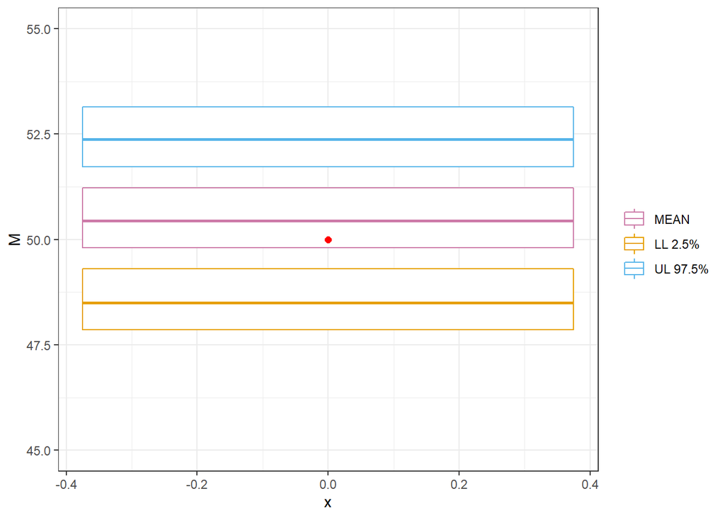

```r
sim <- data.frame(M = sim.mean, SD=sim.sd, LL=sim.ll, UL=sim.ul)

library(ggplot2)
cols=c("MEAN"="#CC79A7","LL 2.5%"="#E69F00", "UL 97.5%"="#56B4E9")
ggplot()+
  geom_boxplot(data=sim, aes(y=M, color="MEAN"),
               coef=0, outlier.shape=NA)+
  geom_boxplot(data=sim, aes(y=LL, color="LL 2.5%"),
               coef=0, outlier.shape=NA)+
  geom_boxplot(data=sim, aes(y=UL, color="UL 97.5%"),
               coef=0, outlier.shape=NA)+
  geom_point(aes(x=0,y=50), color="red",size=2)+
  scale_color_manual(name=NULL,values=cols)+
  lims(y=c(45,55))+
  theme_bw()
```

Now let’s sample differently…

## Stratified random sample

For this I’ll sample say 20 observations from each group.

```r
nsim <- 1000
sim.mean <- numeric(nsim)
sim.sd <- numeric(nsim)
sim.ll <- numeric(nsim)
sim.ul <- numeric(nsim)
sim.cov <- numeric(nsim)
i <- 1
for(i in 1:nsim){
  yi <- unlist(tapply(popdata[,1], popdata[,2], sample, size=20))

  dati <- list(n=length(yi), Y=yi)
  fit <- stan(model_code=model, data = dati,
            chains = 1, iter = 1000, refresh=0)
  mu_ss <- extract(fit)$mu
  sim.mean[i] <- mean(mu_ss)
  sim.sd[i] <- sd(mu_ss)
  sim.ll[i] <- quantile(mu_ss, 0.025)
  sim.ul[i] <- quantile(mu_ss, 0.975)
  sim.cov[i] <- (sim.ll[i] < mu) & (sim.ul[i] > mu)
}

# coverage
mean(sim.cov)
```

```
## [1] 0.942
```

```r
# Average Width
mean(sim.ul - sim.ll)
```

```
## [1] 3.874404
```

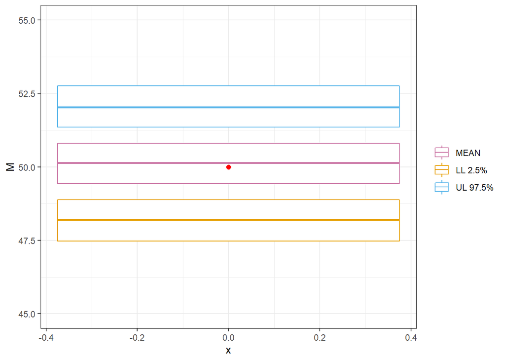

```r
sim <- data.frame(M = sim.mean, SD=sim.sd, LL=sim.ll, UL=sim.ul)


cols=c("MEAN"="#CC79A7","LL 2.5%"="#E69F00", "UL 97.5%"="#56B4E9")
ggplot()+
  geom_boxplot(data=sim, aes(y=M, color="MEAN"),
               coef=0, outlier.shape=NA)+
  geom_boxplot(data=sim, aes(y=LL, color="LL 2.5%"),
               coef=0, outlier.shape=NA)+
  geom_boxplot(data=sim, aes(y=UL, color="UL 97.5%"),
               coef=0, outlier.shape=NA)+
  geom_point(aes(x=0,y=50), color="red",size=2)+
  scale_color_manual(name=NULL,values=cols)+
  lims(y=c(45,55))+
  theme_bw()
```

1. Weighting the likelihood function by the inverse of the probability of inclusion
2. Explicitly modeling the levels of the design
3. Modeling generativey

### Weighted Likelihood Method

Weighting the likelihood can go my various names such as pseudo-likelihood as well. Because cases are weighted differentially, the likelihood is not a true likelihood and may case some issues in the estimation. So instead of a normal likelihood, we can have

$$\ell(Y \mid \theta) = \sum w_if(y_i \mid
\theta)$$

```r
model <- "
data {
  int n;
  real Y[n];
  real pi[n];
}

parameters {
  real mu;
}

model {
  //data model
  for(i in 1:n){
    target += inv(pi[i])*normal_lpdf(Y[i]| mu, 10);
  }
  //prior
  mu ~ normal(50,20);
}

"
```

```r
nsim <- 1000
sim.mean <- numeric(nsim)
sim.sd <- numeric(nsim)
sim.ll <- numeric(nsim)
sim.ul <- numeric(nsim)
sim.cov <- numeric(nsim)
i <- 1
for(i in 1:nsim){
  yi <- unlist(tapply(popdata[,1], popdata[,2], sample, size=20))
  pi <- c(0.00025,0.0003,0.001,0.001,0.001)
  dati <- list(n=length(yi), Y=yi, pi=sort(rep(pi, 20)))
  fit <- stan(model_code=model, data = dati,
            chains = 1, iter = 1000, refresh=0)
  mu_ss <- extract(fit)$mu
  sim.mean[i] <- mean(mu_ss)
  sim.sd[i] <- sd(mu_ss)
  sim.ll[i] <- quantile(mu_ss, 0.025)
  sim.ul[i] <- quantile(mu_ss, 0.975)
  sim.cov[i] <- (sim.ll[i] < mu) & (sim.ul[i] > mu)
}

# coverage
mean(sim.cov)
```

```
## [1] 0.028
```

```r
# Average Width
mean(sim.ul - sim.ll)
```

```
## [1] 0.08509881
```

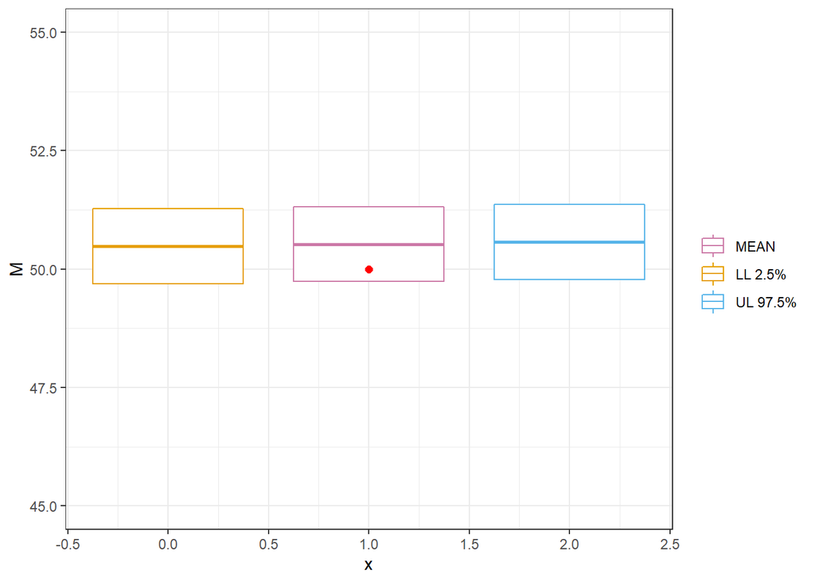

```r
sim <- data.frame(M = sim.mean, SD=sim.sd, LL=sim.ll, UL=sim.ul)


cols=c("MEAN"="#CC79A7","LL 2.5%"="#E69F00", "UL 97.5%"="#56B4E9")
ggplot()+
  geom_boxplot(data=sim, aes(y=M, x=1, color="MEAN"),
               coef=0, outlier.shape=NA)+
  geom_boxplot(data=sim, aes(y=LL,x=0, color="LL 2.5%"),
               coef=0, outlier.shape=NA)+
  geom_boxplot(data=sim, aes(y=UL, x=2, color="UL 97.5%"),
               coef=0, outlier.shape=NA)+
  geom_point(aes(x=1,y=50), color="red",size=2)+
  scale_color_manual(name=NULL,values=cols)+
  lims(y=c(45,55))+
  theme_bw()
```

So, that was poor…